# ITTF Dataset Exploration

KF

## Background

These datasets were obtained from [Kaggle](https://www.kaggle.com/datasets/romanzdk/ittf-table-tennis-player-rankings-and-information) and shows the ITTF rankings of players between the years 2001-2020.

My plan:

1. Import dataset
2. Exploratory Data Analysis
   - distributions
   - anything else that is interesting?
3. Which playing style is most popular? Least popular?

As a table tennis player myself, my ulterior motive is to see which playing style I should try to give my opponents the most headaches. Read this as: least common/rare playing styles.

## Import

Here, I start off by importing the necessary packages and dataset. *Note*: KF.QoL is a custom package I wrote that contains custom functions I wrote to improve my coding/analysis quality of life.

### Packages + Functions

```r
#Core packages/functions
gc()
```

```
##          used (Mb) gc trigger (Mb) limit (Mb) max used (Mb)
## Ncells 513340 27.5    1133231 60.6         NA   666908 35.7
## Vcells 950183  7.3    8388608 64.0      16384  1824122 14.0
```

```r
library(KF.QoL)
library(tidyverse)
# library(data.table)
# library(readxl)

#Additional packages
library(bslib)
```

## Player Info Dataset

Since I expect the dataset to have a large number of rows, I will be using data.table to read in the csv files.

```r
player_info <- KF.QoL::soleImport("~/Desktop/KaggleData/ITTF/ittf_player_info.csv")
```

### EDA

When taking a first look at the data, I notice some players have “-” for one or more of the following:

1. Playing hand
2. Playing style
3. Grip

As such, I want to take a closer look at the type of missingness this is. To simplify things, I am filtering for the rows I am interested in (have “-” in at least 1 of the 3 listed variables).

```r
info_temp <- player_info %>% filter(`Playing hand`=="-"|`Playing style`=="-"|`Grip`=="-")
```

The number of rows went from 37620 to 1582.

```r
#go over all vars (except Player ID & Name) to print out unique values
numLvls <- lapply(names(info_temp)[-(1:2)],function(x){
  (unique(info_temp[[x]]))
})

#add names (to avoid any confusions)
names(numLvls) <- names(info_temp)[-(1:2)]
```

From this result, I all aspects of the player’s style is unknown. A large number:

ASA, RUS, USA, BRN, DJI, AFG, KSA, AZE, ALG, ETH, PLE, RSA, GHA, DOM, VEN, CHA, BEN, NZL, TOG, ISL, ALB, FRA, CRC, COM, BAN, CMR, CIV, MDV, PAK, LBN, IRQ, KUW, ECU, ANG, BIZ, SYR, CAN, WAL, ISR, MAR, PAN, ERI, COD, IRI, DEN, MEX, MRI, EST, SGP, IND, CUB, BLR, HKG, LTU, PUR, GER, HON, INA, NOR, SLE, VIN, PHI, CGO, ITA, SEY, GUI, UAE, SOL, ENG, MGL, CZE, TAN, POL, QAT, SVK, SUR, SWE, NCA, PNG, ARU, BEL, GAB, MDA, TCH, NED, AUS, CAM, RWA, MKD, COL, SCO, LUX, GUA, CHI, GRE, FIN, CHN, TPE, PRK, PER, CYP, ESA, JAM, SRB, BRA, PYF, MLT, HAI, BUR, TUN, MAD, VIE, FRO, TUR, TTO, UKR, NGR, LCA, IRL, POR, BUL, MTN, EGY, SAM, LBA, JPN, SUI, HUN, LAT, MAS, ARM, AUT, MON, GUY, SRI, BAR, LBR, SMR, CRO, GEO, KOS, ZAM, GRL, BOL, SKN, MAW, COK, BOT, KEN, KOR, NEP, TKM, LAO, MAC, BIH, ARG, UGA, VAN, TGA, ROU, FIJ, UZB, BAH, YEM, MLI, PLW, MYA, NAM, KGZ, JEY, DMA

of Associations are represented. Males and Females are represented. A wide range of birth years are represented. But, there is at least one instance of NA and “0”. Players that are Active, Inactive are represented.

#### Questions I have (for this subset of data):

- What is the difference between “-” and NA for the player’s style? Are they the same?
- What does “^^” next to name mean?
  - How many have that?
- Which years are not represented here?
  - Is it due to players not being born on that year?
  - Or is there a hidden correlation?
- What is distribution on: gender, association, activity

#### Plotting Distributions

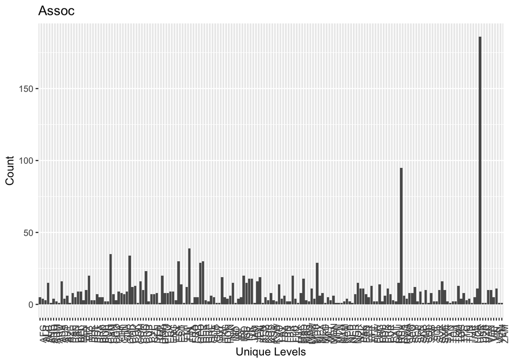

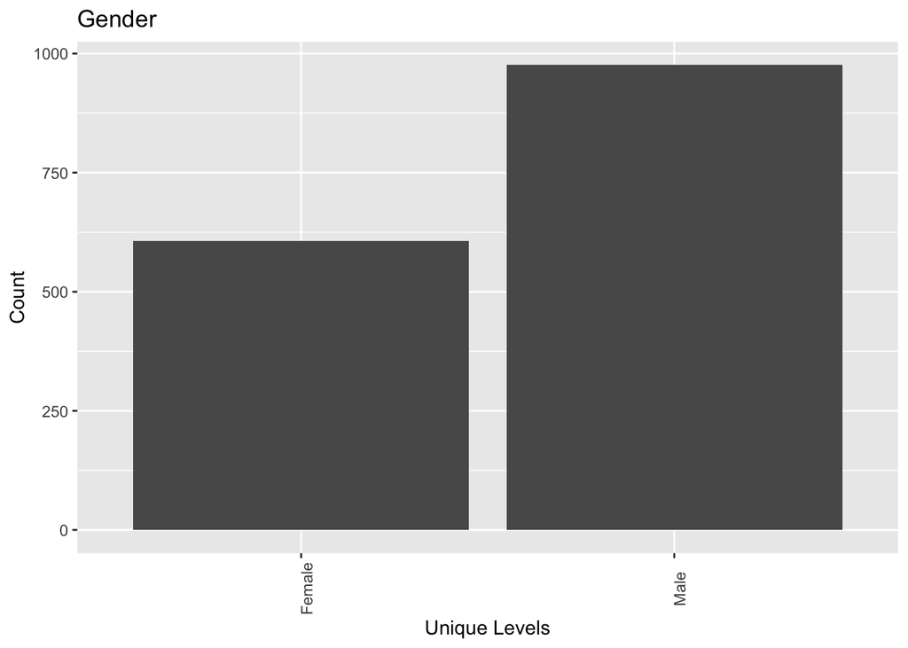

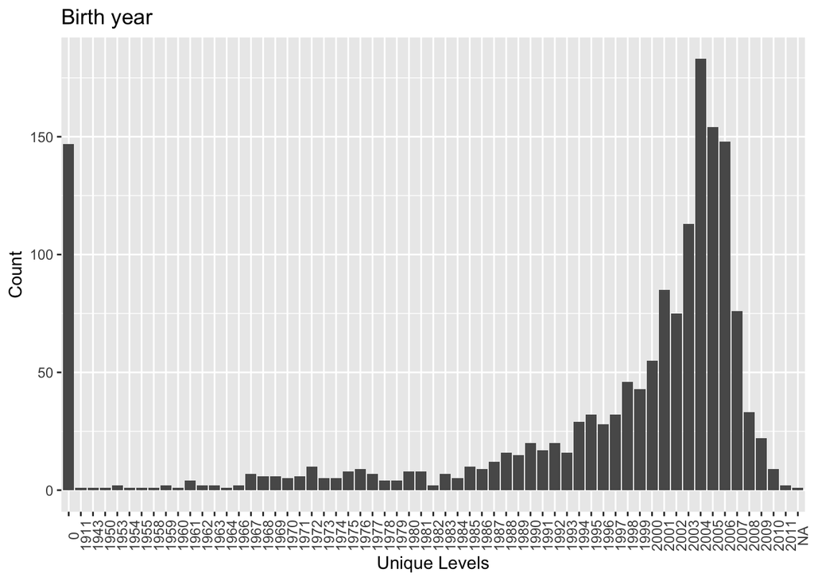

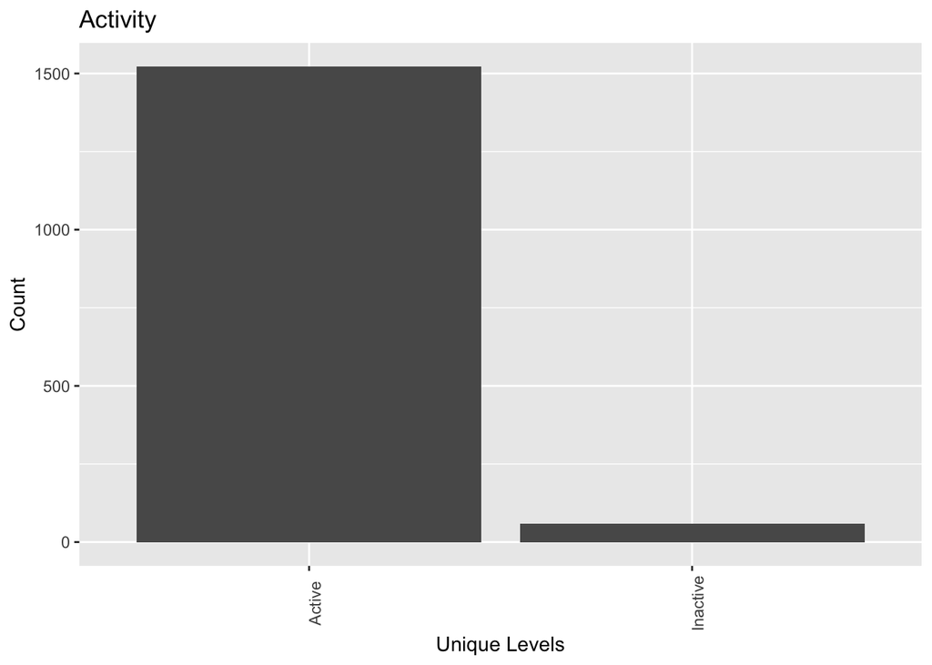

```r
#list of vars I want to view distribution of
varOfInterest <- names(numLvls)[1:4]

#print out all 4 plots using custom function
lapply(varOfInterest,function(varName){
  ggplot(info_temp,aes(info_temp[[varName]]))+ #removed ,fill=info_temp[[varName]]
    geom_bar(stat="count")+
    labs(title=varName,x="Unique Levels",y="Count")+
    theme(axis.text.x=element_text(angle=90))
})
```

```r
rm(numLvls,varOfInterest)
```

Note: I chose to not use color/fill because it caused loading issues. Will have to fix/create plot for “Association” col.

From the output histograms, those that have “-” listed as their style:

- 2 associations have > 50 players
- Males > Females
- ~150 for Birth year = 0, <10 for Birth year = NA
- majority are born in early 2000s
- significant portion Active compared to Inactive

Other question(s) that arose:

- How were the data collected?
- How many are sponsored players?
  - sponsored players are more likely to disclose their equipment
- Does ranking explain this?
- How about social media presence?
  - somewhat correlated to being a sponsored player

#### Players whose style is NA

```r
info_na <- player_info %>% filter(is.na(`Playing hand`)|is.na(`Playing style`)|is.na(`Grip`))
```

A very large number of rows 28113 have NA for 1+ aspect of their playing style. In fact, all entries for these 3 columns are NA!

```r
#skipped for now
```

## Removed “-” and NA

```r
#using anti_join and %>%
player_info_v1 <- player_info %>% anti_join(info_na,by=c("Player ID","Name")) %>%
                    anti_join(info_temp,by=c("Player ID","Name"))
```

```r
#view birth year=0
player_info_yr0 <- player_info_v1 %>% filter(`Birth year`==0)

#rm those w/
player_info_v1 <- anti_join(player_info_v1,player_info_yr0,by=c("Player ID","Name"))
```

NGR, KSA, PLE, OMA, ECU, INA, CRO, SEN, PUR, MGL, SVK, SMR, NOR, MNE, FRA, GUY, SWE, SRB, TUR, BRU, GUA

Taking a look at the associations, I notice the majority were from smaller countries. Of course, there are some exceptions, such as: France and Sweden.

At this point, I have done cleaning the `Player Info` dataset and will move onto the men’s rankings dataset.

```r
#rm vars
rm(info_na,info_temp,player_info,player_info_yr0)
```

## Men’s Rankings Dataset

```r
#import dataset, has option for data.table
rankings_m <- KF.QoL::soleImport("~/Desktop/KaggleData/ITTF/ittf_rankings.csv")

#all rows for PreviousPoints & WeekNum=0 (removed)
rankings_m <- rankings_m %>% select(-c("Previous Points","WeekNum"))

#convert selected cols to numeric
rankings_m[,c("Rank","Previous","Points","MonthNum","YearNum")] <- lapply(rankings_m[,c("Rank","Previous","Points","MonthNum","YearNum")],as.numeric)
```

The rankings dataset can first be split by year. I might consider splitting by month or week later on.

```r
#by year
male_rankings <- split(rankings_m,rankings_m$YearNum)

#by month (within year)
for(i in 1:length(male_rankings)){
  temp_df <- male_rankings[[i]]
  male_rankings[[as.character(names(male_rankings)[i])]] <- split(temp_df,temp_df$MonthNum)
}

#find years where there are less than 12 months of data
months_present <- unlist(lapply(male_rankings,length))
```

While there is data for all 12 months for most years, there are 3 with 11 months, 1 with 2 months, and 2 with 1 month.

2009,2019,2020 were abnormalities that occurred due to pandemics: swine-flu for 2009 and COVID-19 for 2019,2020

```r
#keep data from last timepoint
for(i in 1:length(male_rankings)){
  male_rankings[[i]] <- male_rankings[[i]][[length(male_rankings[[i]])]]
}

#turn back into df form
male_rankings_v1 <- bind_rows(male_rankings)
```

### Add Playing Style

```r
#vars I want to add
style_list <- c("Playing style","Playing hand","Grip")

#loop to add vars using custom function
for(i in 1:length(style_list)){
  varName <- style_list[i]
  male_rankings_v1[[varName]] <- KF.QoL::match_n_fill(player_info_v1$Name,male_rankings_v1$Name,
                                          player_info_v1[[varName]])
}

#rm other classes
male_rankings_v1 <- as.data.frame(male_rankings_v1)

rm(male_rankings,months_present,style_list,varName)
```

## What is the dominant playing style of the top 100 ranked players?

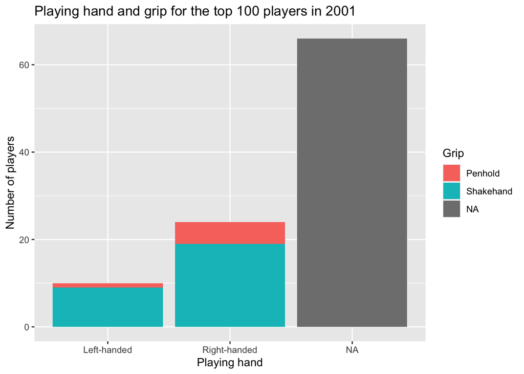

```r
#just top 100 players per year
male_rankings_v2 <- male_rankings_v1 %>% group_by(YearNum) %>% filter(Rank<=100)

#celluloid vs plastic ball era
male_rankings_v2$Era <- ifelse(male_rankings_v2$YearNum<=2014,"Celluloid","Plastic")
male_rankings_v3 <- split(male_rankings_v2,male_rankings_v2$Era)

#playing hand
male_rankings_v3$Celluloid %>% filter(YearNum==2001) %>%
  ggplot(aes(`Playing hand`,fill=`Grip`))+
  geom_bar(stat="count")+
  labs(y="Number of players",
    title=paste("Playing hand and grip for the top 100 players in","2001",sep=" "))
```

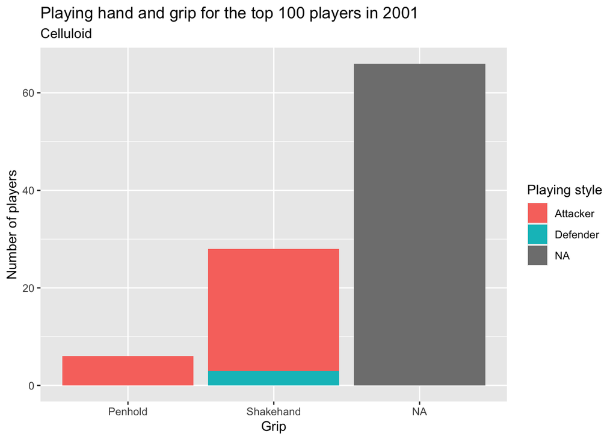

```r
#playing style
male_rankings_v3$Celluloid %>% filter(YearNum==2001) %>%
  ggplot(aes(`Grip`,fill=`Playing style`))+
  geom_bar(stat="count")+
  labs(y="Number of players",
    title=paste("Playing hand and grip for the top 100 players in","2001",sep=" "),
    subtitle=paste(male_rankings_v3$Celluloid$Era),"Era",sep=" ")
```

```r
rm(male_rankings_v1,male_rankings_v2)
```

## Conclusion

Ignoring the NAs, it seems like the **most** popular style is **Right handed shakehand grip attacker**. The **least** popular style would be Left hand penhold grip defender.

Although the data seems to indicate I should be playing a defensive style using a left hand penhold grip, there are other details (from domain expertise) that were glossed over.

1. Most people in the world are right-handed.
2. Penhold style is rare/non-existent outside of Asian countries.
3. Penhold style’s advantages, especially during the celluloid ball era, are: deceptive serves and extra wrist flexibility/movement to impart more spin on the ball.
   - Both of these allow penholders to set up a strong 3<sup>rd</sup> ball attack.
4. Mastering the penhold style can be difficult.
   - There are many grip variations: traditional Chinese penhold, Japanese/Korean penhold, and RPB (reverse penhold backhand). Each has their advantages and disadvantages.
   - All of the grip variations have a (relatively/subjectively) steeper learning curve for the backhand side compared to the shakehand grip.

Taking into account all of these insights, I plan to use right hand shakehand defensive style although I might experiment with right hand penhold defensive style.

Other factors that were not considered are pips vs inverted sheet and type of forehand and backhand rubber.

### Future Directions

As I continue to explore and analyze this dataset, I plan to:

- work on the female rankings dataset
- create more plots (time-series)
- incorporate equipment (blade, forehand+backhand rubbers)
- tidy my code

```r
rm(temp_df,rankings_m)
```